# USA House Price Analysis

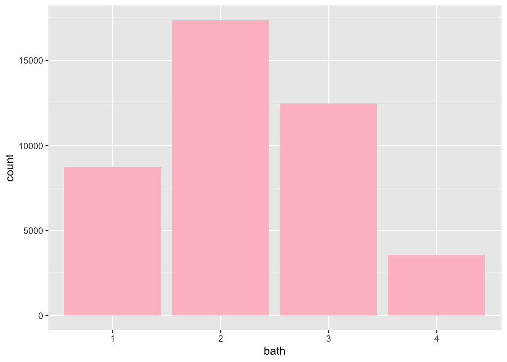

```r
ggplot(df, aes(bath)) + geom_bar(fill="pink")
```

From these bar plots, we can observe that there are more houses with median number of bedrooms and bathrooms. This confirms the earlier hypothesis that there are more average sized houses than small or large houses.

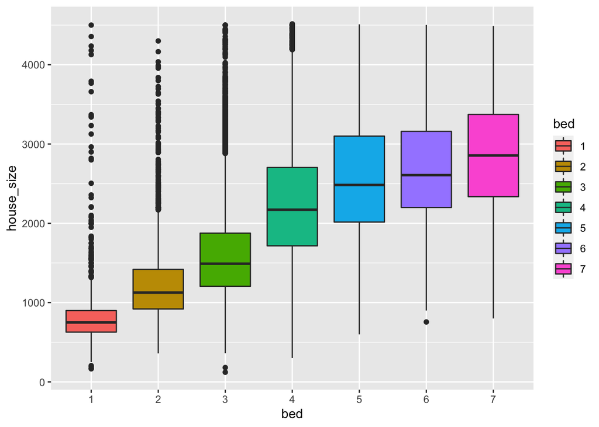

```r
ggplot(df, aes(bed, house_size,fill=bed)) + geom_boxplot()
```

The boxplot provides the distribution of the house_size with respect to the number of beds. It also shows the obvious distribution of the houses being bigger as the number of bedrooms gets higher.

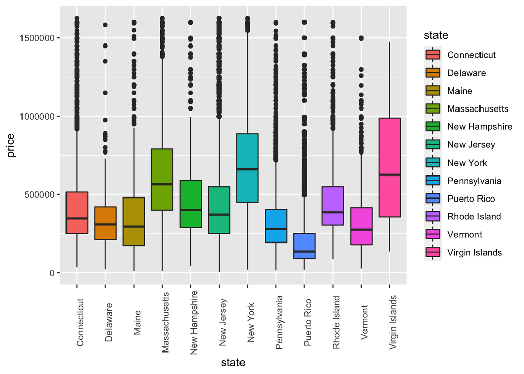

```r
ggplot(df, aes(state, price, fill= state)) + geom_boxplot() + theme(axis.text.x = element_text(angle = 90))
```

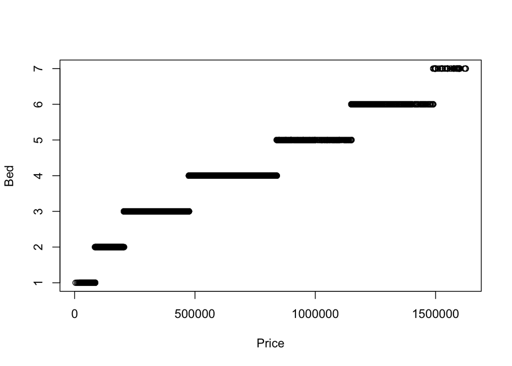

```r
qqplot(df$price, df$bed, xlab = 'Price', ylab = 'Bed')
```

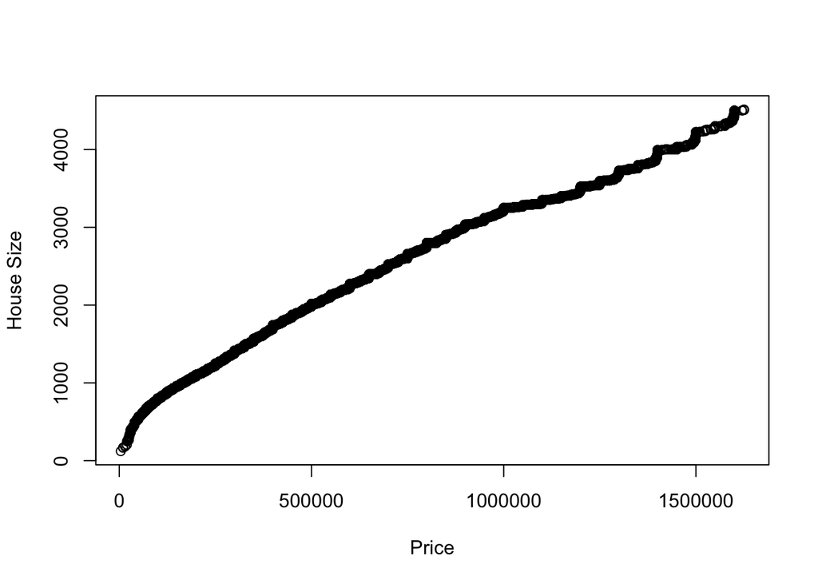

```r
qqplot(df$price, df$house_size, xlab = 'Price', ylab = 'House Size')
```

## 0.2 Testing

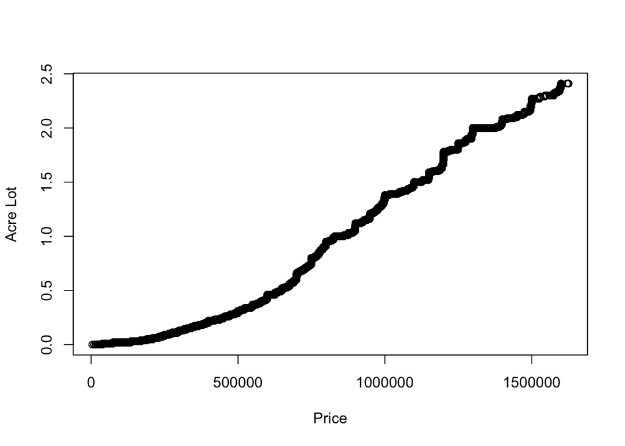

```r
qqplot(df$price, df$acre_lot, xlab = 'Price', ylab = 'Acre Lot')
```

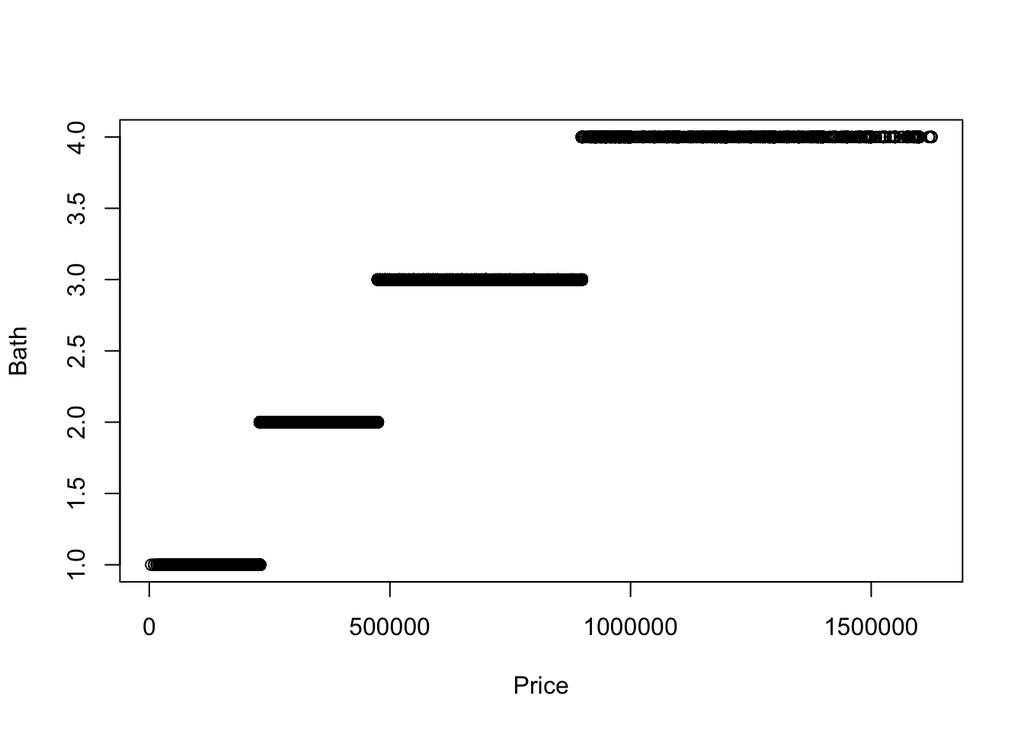

```r
qqplot(df$price, df$bath, xlab = 'Price', ylab = 'Bath')
```

```r
anova_hb <- aov(price ~ bed, data= df)
anova_hb_summary <- summary(anova_hb)
anova_hb_summary
xkabledply(anova_hb)
```

```r
tukey_test <- TukeyHSD(anova_hb)
tukey_test
```

```r
anova_hbath <- aov(price ~ bath, data= df)
anova_hbath_summary <- summary(anova_hbath)
anova_hbath_summary
xkabledply(anova_hbath)
```

```r
tukey_test_hbath <- TukeyHSD(anova_hbath)
tukey_test_hbath
```

```r
contable = table(df$bed, df$bath)

xkabledply(contable, title="Contingency table for beds vs baths in house_dataframe")
```

```r
chitest = chisq.test(contable)
chitest
```

```r
head(df)
df_forcorr <- df
df_forcorr$bed = as.integer(df_forcorr$bed)
df_forcorr$bath = as.integer(df_forcorr$bath)

df_forcorr <-  subset(df_forcorr, select = -c(city,state,zip_code ))
str(df_forcorr)
corr = cor(df_forcorr)
corr
```

```r
loadPkg("corrplot")
```

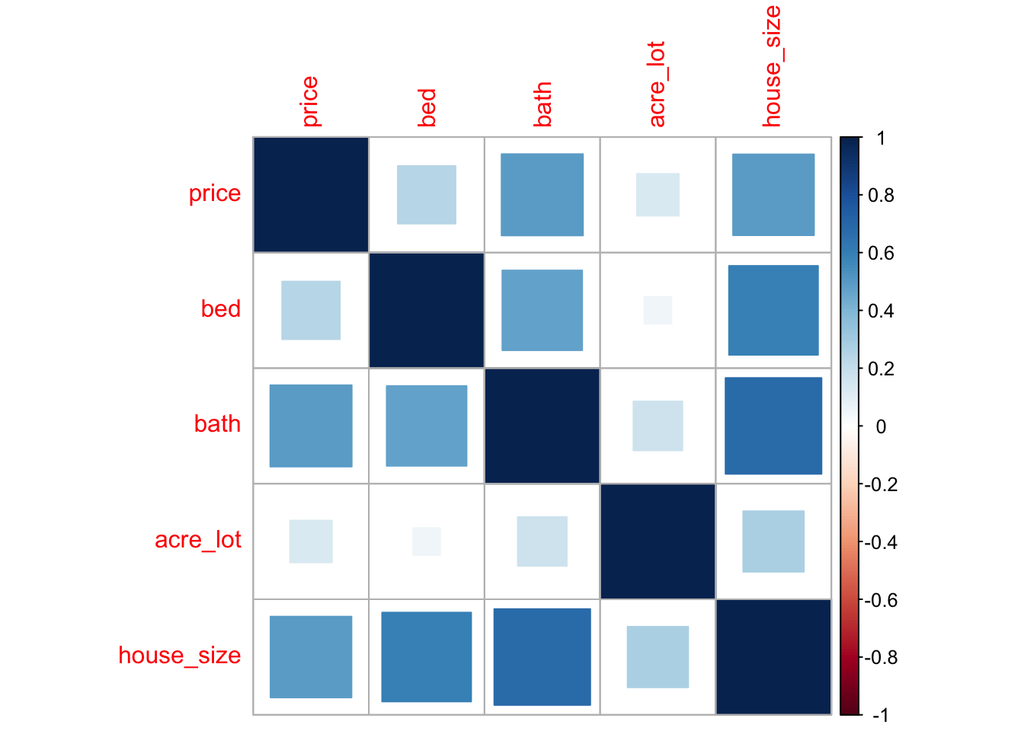

```r
corrplot(corr, method = "square")
```

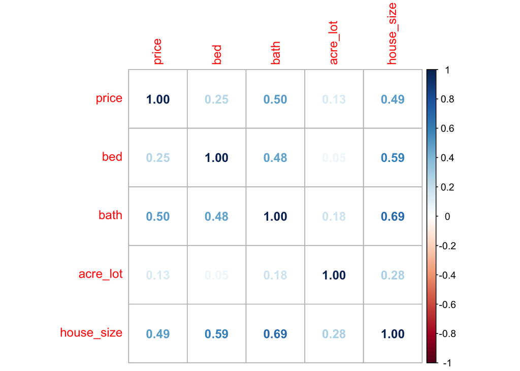

```r
corrplot(corr, method = "number")
```

```r
head(df)
stats<-data.frame(df %>% group_by(state) %>% summarise(mean = mean(price), median = median(price), max= max(price), min = min(price), sd = sd(price)))
```

```r
head(stats)
str(stats)
```

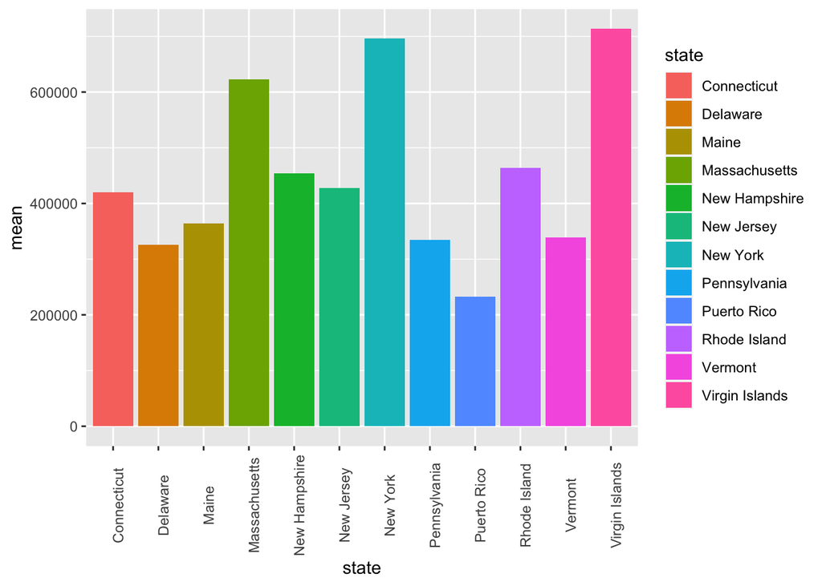

```r
ggplot(stats, aes(x = state, y = mean, fill = state)) +
  geom_bar(stat = "identity") + theme(axis.text.x = element_text(angle=90))
```

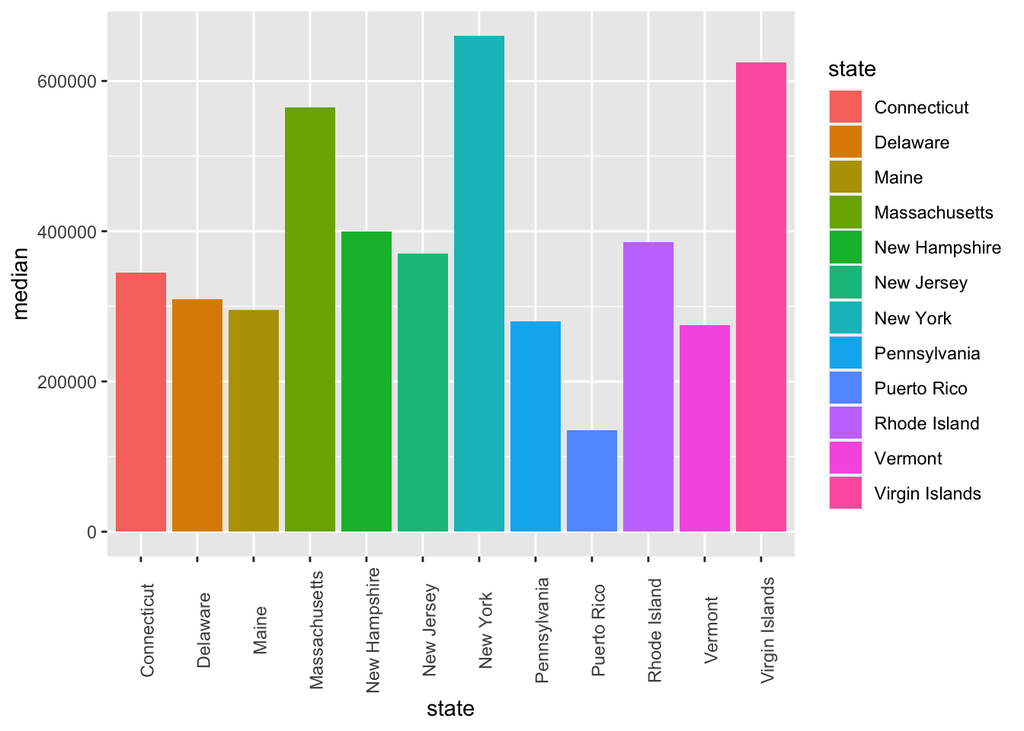

```r
ggplot(stats, aes(x = state, y = median, fill = state)) + geom_bar(stat = "identity") + theme(axis.text.x = element_text(angle=90))
```

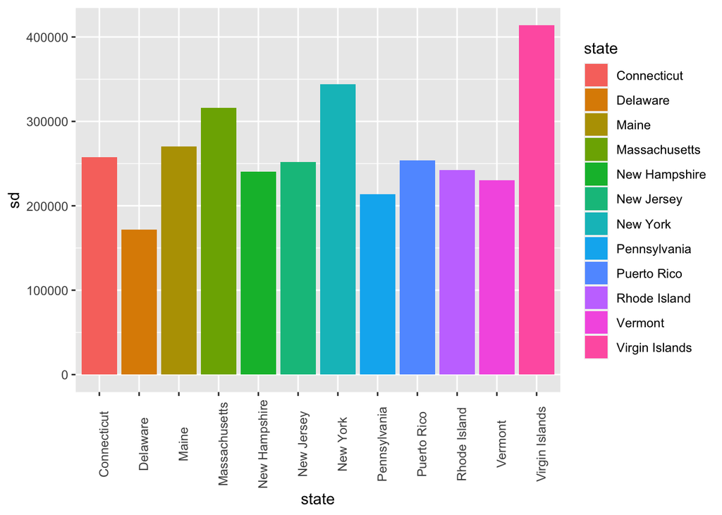

```r
ggplot(stats, aes(x = state, y = sd, fill = state)) + geom_bar(stat = "identity") + theme(axis.text.x = element_text(angle=90))
```

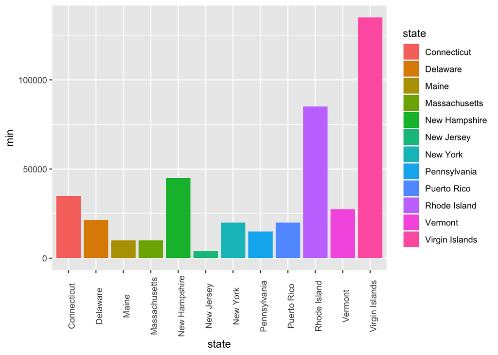

```r
ggplot(stats, aes(x = state, y = min, fill = state)) + geom_bar(stat = "identity") + theme(axis.text.x = element_text(angle=90))
```

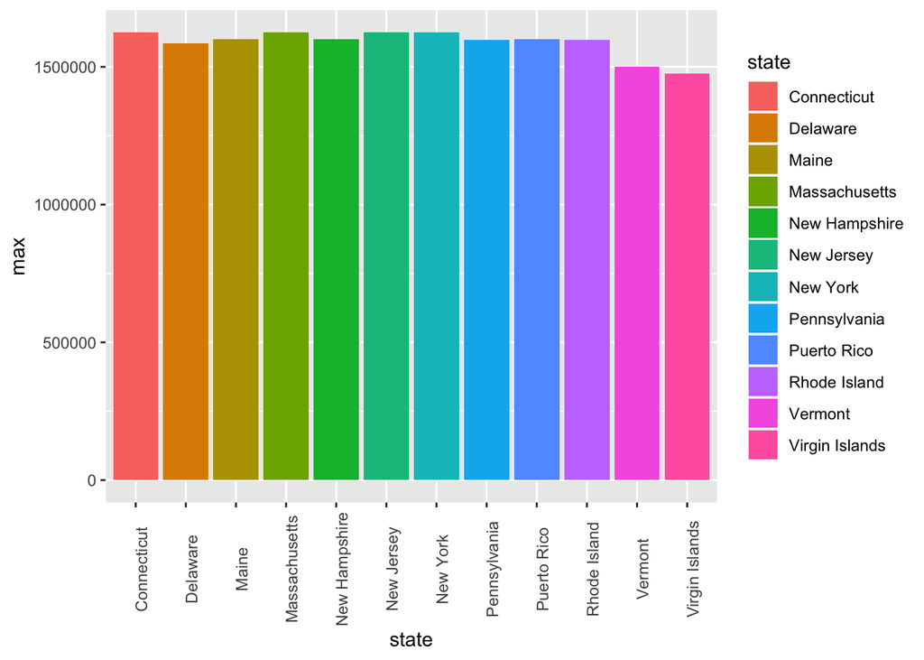

```r
ggplot(stats, aes(x = state, y = max, fill = state)) + geom_bar(stat = "identity") + theme(axis.text.x = element_text(angle=90))
```

```r
head(df)
```

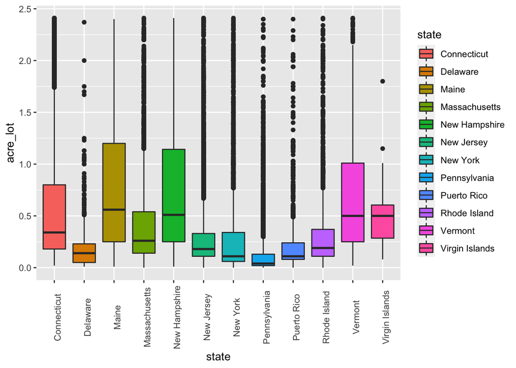

```r
ggplot(df, aes(state, acre_lot, fill = state)) + geom_boxplot() + theme(axis.text.x = element_text(angle=90))
```

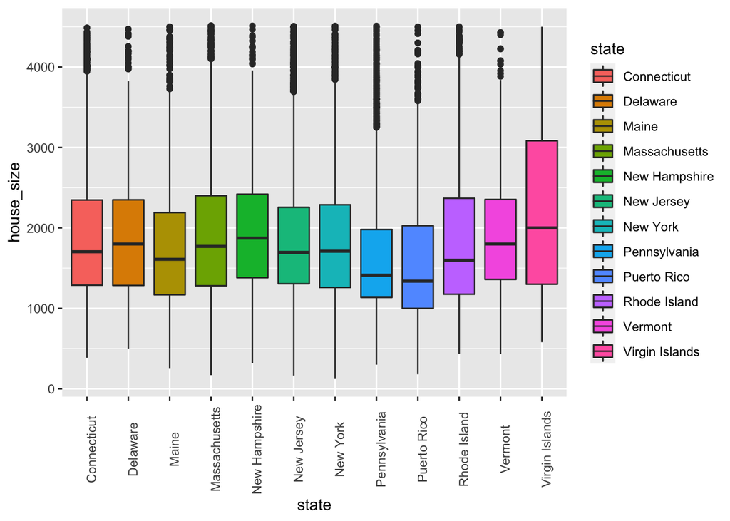

```r
ggplot(df, aes(state, house_size, fill = state)) + geom_boxplot() + theme(axis.text.x = element_text(angle=90))
```

```r
stats_df<-data.frame(df %>% group_by(state) %>% summarise(mean = mean(acre_lot), median = median(acre_lot), sd = sd(acre_lot)))
```

```r
head(stats_df)
```

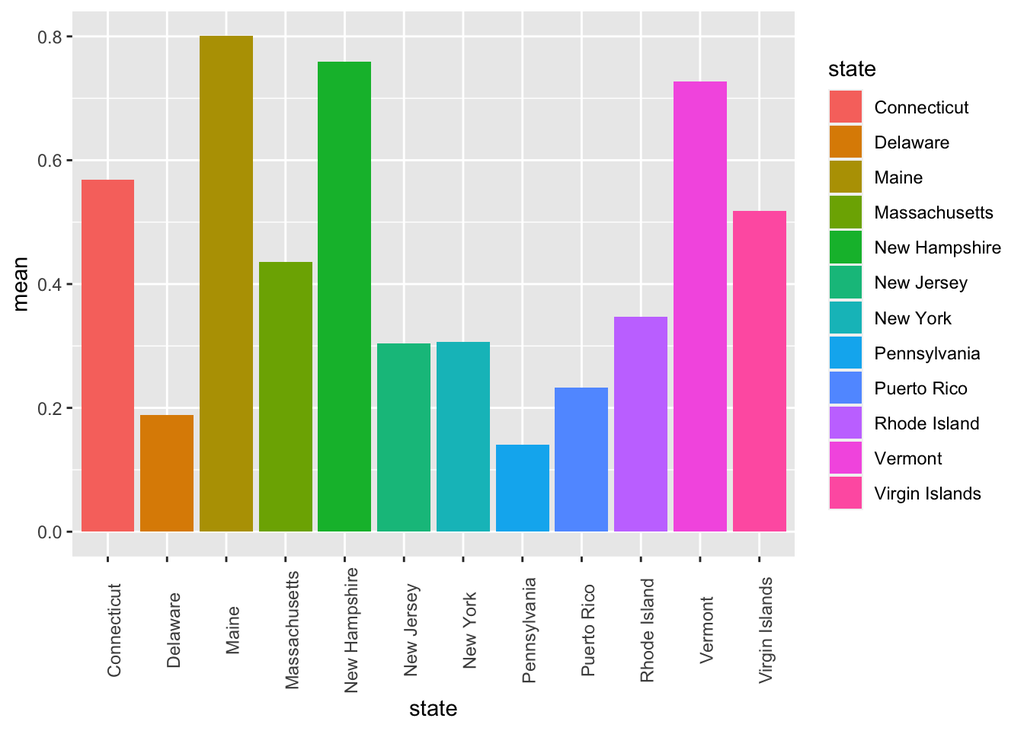

```r
ggplot(stats_df, aes(x = state, y = mean, fill = state)) + geom_bar(stat = "identity") + theme(axis.text.x = element_text(angle=90))
```

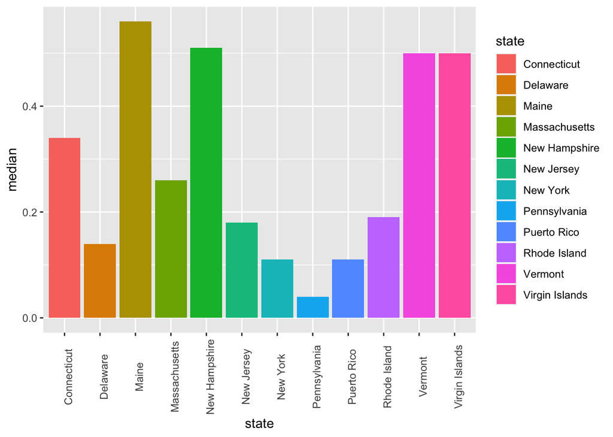

```r
ggplot(stats_df, aes(x = state, y = median, fill = state)) + geom_bar(stat = "identity") + theme(axis.text.x = element_text(angle=90))
```

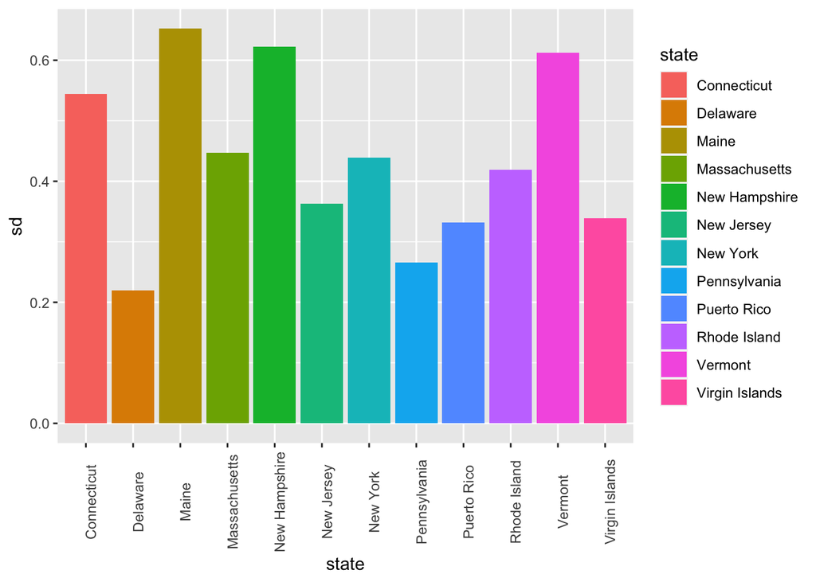

```r
ggplot(stats_df, aes(x = state, y = sd, fill = state)) + geom_bar(stat = "identity") + theme(axis.text.x = element_text(angle=90))
```

```r
stats_df_hs<-data.frame(df %>% group_by(state) %>% summarise(mean = mean(house_size), median = median(house_size), sd = sd(house_size)))
```

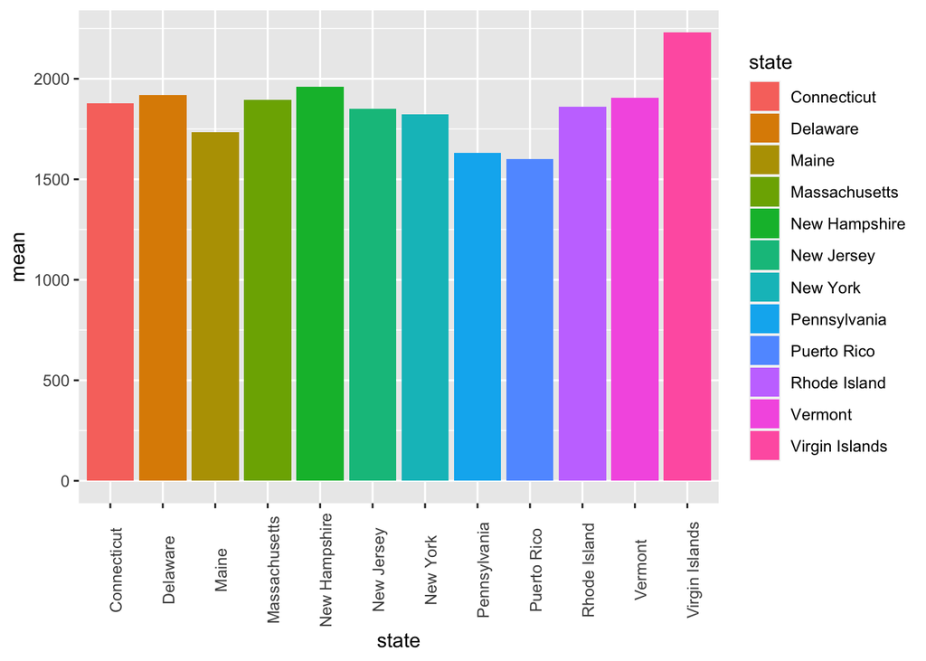

```r
ggplot(stats_df_hs, aes(x = state, y = mean, fill = state)) + geom_bar(stat = "identity") + theme(axis.text.x = element_text(angle=90))
```

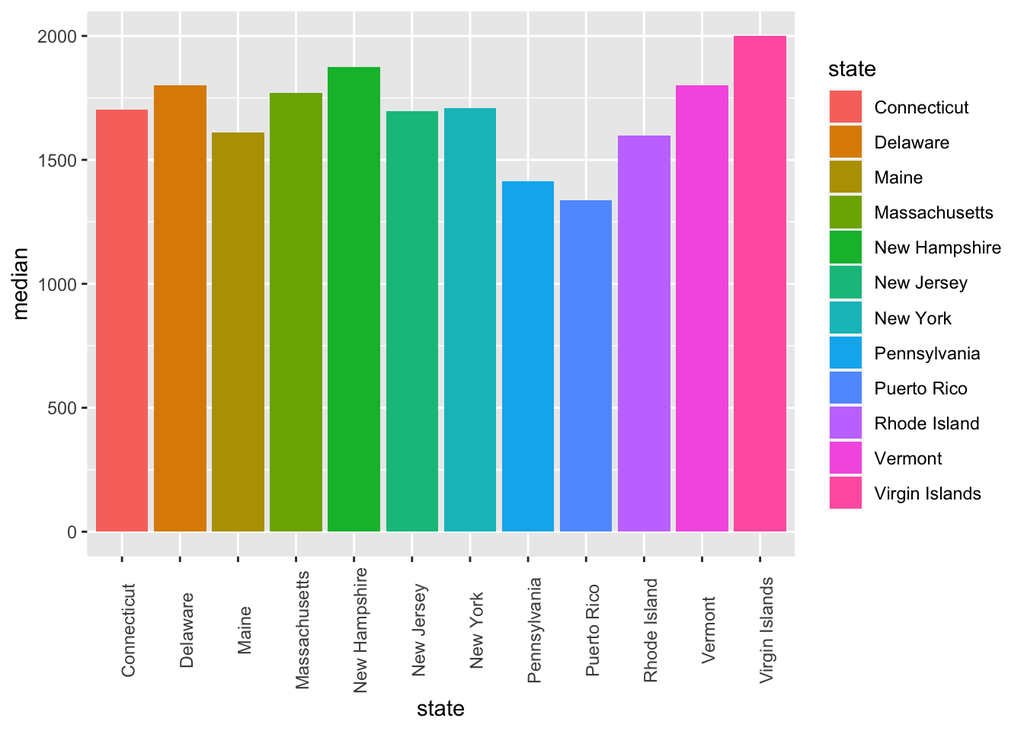

```r
ggplot(stats_df_hs, aes(x = state, y = median, fill = state)) + geom_bar(stat = "identity") + theme(axis.text.x = element_text(angle=90))
```

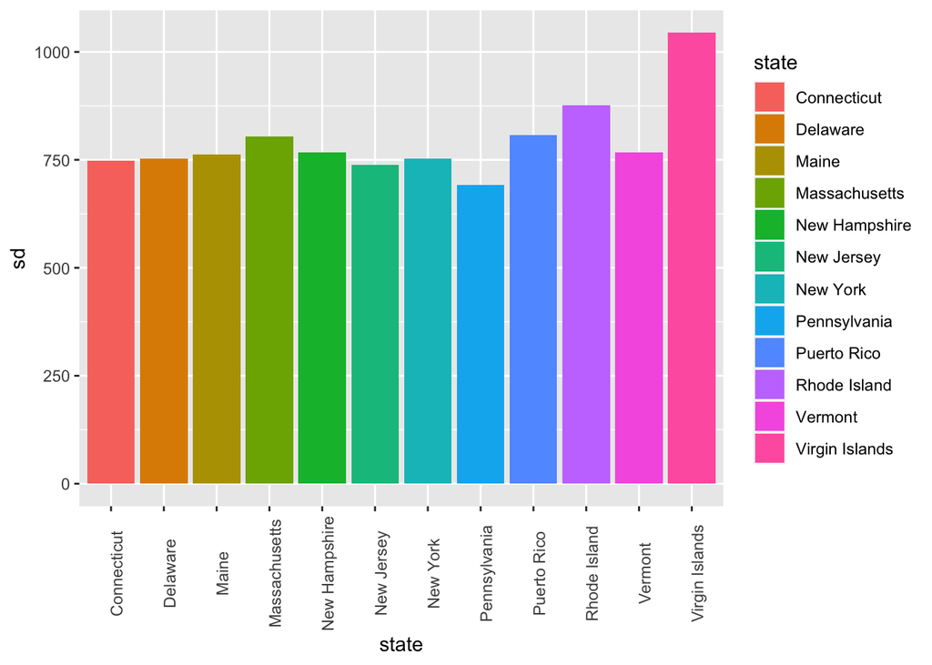

```r
ggplot(stats_df_hs, aes(x = state, y = sd, fill = state)) + geom_bar(stat = "identity") + theme(axis.text.x = element_text(angle=90))
```